# Statistical tests

[interactive chart not shown]

Slides in full screen Download PDF slides

# 1 Task

**Note**

Find the solution here later.

## 1.1 Get started

We will again use the `penguins` tibble from the `palmerpenguins` package for this task.

So before you get started with the exercise, make sure that you load the `palmerpenguins` package and the `tidyverse`

```r
library(palmerpenguins)
library(tidyverse)
```

## 1.2 Compare the flipper length of penguins using statistical tests

Question: Does the mean flipper length differ between the 3 penguin species?

Do separate comparisons for

- Gentoo vs. Adelie
- Gentoo vs. Chinstrap
- Adelie vs. Chinstrap

Before you start, create a subset of each species as a vector.

For this, you can use the `$` operator:

```r
adelie <- filter(penguins, species == "Adelie")$flipper_length_mm
chinstrap <- filter(penguins, species == "Chinstrap")$flipper_length_mm
gentoo <- filter(penguins, species == "Gentoo")$flipper_length_mm
```

Follow the decision tree for statistical tests:

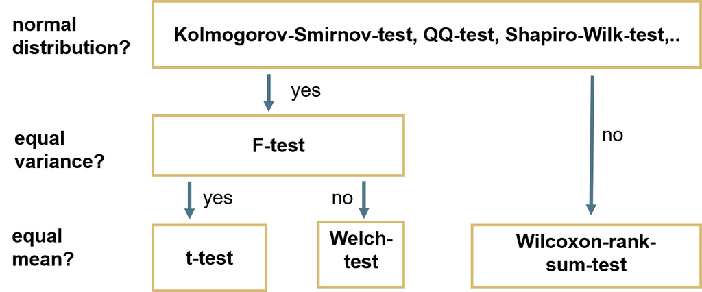

## 1.3 Extra

Create a plot to show the results of your tests. Choose one of the following:

- Create a boxplot with notches to visually compare differences in flipper length between species
- Make a plot showing the mean and standard error of the mean as pointrange or point with errorbars

Add a `geom_signif()` layer to the plot you just created to indicate your test results